# Udacity Project

## Sean Lahman's Baseball data

I have analyzed the baseball data in the http://www.seanlahman.com website. The site contains the complete baseball statistics from 1871 to 2016 in various datasets. I have analyzed the 'Salaries', 'Teams','AllstarFull','Batting;,'Pitching','HallofFame' csv files in specific.

### Questions?

1. How has the attendance varied from year to year?
2. What is the trend of the average salary for a baseball player over the years?
3. How does the average salary of all star players compare to non allstar players?
4. Which league, the National league or the American league has won the most number of world series title?
5. What percent of people nominated for the Hall of Fame finally get voted into it?
6. How are the performance stats for a player in the Hall of Fame? etc.

#### 1.How has the attendance varied from year to year?

One thing interesting about any league is the fan attendance to games.It shows the popularity of the sport in the country and is a good sign that the league is drawing good money. In the Teams.csv file, among many stats is the home attendance total for a particular team. How has the attendance varied from year to year? To answer this question, the mean home attendance per year is analyzed.

```python
import pandas as pd
import numpy as np
import matplotlib.pyplot as plt
import seaborn as sns
```

```python
#Load csv file to variable Teams
Teams=pd.read_csv('Teams.csv')
```

[output not shown]

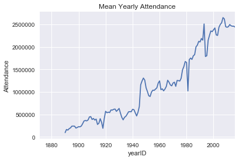

```python
#Group Teams dataframe by yearID and selecting only the attendance column.
Groupby_data=Teams.groupby('yearID')['attendance']

#Finding the mean total attendance per year
Attendance_mean=Groupby_data.mean()

#The graph of the mean
%pylab inline
Attendance_mean.plot(x='yearID')
plt.ylabel("Attendance ")
plt.title('Mean Yearly Attendance')
```

As visible from the graph, there has been 2 sudden drops in attendance observed over the years.

```python
#Largest drop in attendance

Largest_drop=(Attendance_mean-Attendance_mean.shift(1)).argmin()
Largest_drop
```

```
1994
```

The above code shows that the largest drop in attendance occured in the year 1994. This makes us wonder about the reason for the drop could be?

```python
#Teams data from the year 1993 and 1994
Teams_1993=Teams[Teams['yearID']==1993]
Teams_1994=Teams[Teams['yearID']==1994]
print (Teams_1993['G'])
print (Teams_1994['G'])
```

```
2125    162
2126    162
2127    162
2128    162
2129    162
2130    163
2131    162
2132    162
2133    162
2134    162
2135    162
2136    162
2137    162
2138    162
2139    162
```

[output cut: 43 more lines]

From the above piece of code we can see that the games played in the year 1994 compared to the year 1993 is less and also on checking about the year 1994 in the 'SeriesPost'.csv,the year is found to be missing in the csv file stating that the post season did not happen for that year.This explains the drop in the attendance average. On furthur examining about the season online, it seems like there was a player strike in the year 1994.

#### 2.What is the trend of the average salary for a baseball player over the years?

```
 For this question the 'Salaries.csv' file has been analyzed.
```

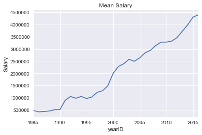

```python
Salaries=pd.read_csv('Salaries.csv')
Salary_mean=Salaries.groupby('yearID')['salary'].mean()
%pylab inline
Salary_mean.plot(x='yearID')
plt.title("Mean Salary");
plt.ylabel("Salary")
```

From the above graph it is clear that the average salary has increased almost exponentially over the years with it peaking at 4,396,409 in 2016.

#### 3.How does the average salary of all star players compare to non allstar players?

An allstar is an athlete chosen as the best at his position from all teams in league. Comparing the salaries of Allstar players and non Allstar players would give some interesting data.Since the data in the 'Salaries.csv' file is from the year 1985, the players from that year are being considered.

```python
#Reading all star data
Allstar_data=pd.read_csv('AllstarFull.csv')
```

```python
#Data from the year 1985
Allstar_data_1985=Allstar_data[Allstar_data['yearID']>=1985]
```

```python
Allstar_data_1985.head()
```

|  | playerID | yearID | gameNum | gameID | teamID | lgID | GP | startingPos |
| --- | --- | --- | --- | --- | --- | --- | --- | --- |
| 3023 | morrija02 | 1985 | 0 | ALS198507160 | DET | AL | 1.0 | 1.0 |
| 3024 | fiskca01 | 1985 | 0 | ALS198507160 | CHA | AL | 1.0 | 2.0 |
| 3025 | murraed02 | 1985 | 0 | ALS198507160 | BAL | AL | 1.0 | 3.0 |
| 3026 | whitalo01 | 1985 | 0 | ALS198507160 | DET | AL | 1.0 | 4.0 |
| 3027 | brettge01 | 1985 | 0 | ALS198507160 | KCA | AL | 1.0 | 5.0 |

```python
#Finding average salary for an all star player
def salary_allstar(f):
    t = Salaries[Salaries['playerID']==f]
    y=t['salary'].mean()
    return {f:y}
```

```python
d = Allstar_data_1985['playerID'].apply(salary_allstar)
Allstar_Salary=pd.DataFrame(columns=["playerID", "average_salary"])
for i in d:
    for key,val in i.items():
            Allstar_Salary=Allstar_Salary.append({
                   "playerID": key,
                    "average_salary":  val
                         },ignore_index=True)
Allstar_Salary
```

|  | playerID | average_salary |
| --- | --- | --- |
| 0 | morrija02 | 2.237455e+06 |
| 1 | fiskca01 | 1.045000e+06 |
| 2 | murraed02 | 2.331479e+06 |
| 3 | whitalo01 | 1.796364e+06 |
| 4 | brettge01 | 2.227381e+06 |
| 5 | ripkeca01 | 4.108824e+06 |
| 6 | riceji01 | 1.888653e+06 |
| 7 | henderi01 | 2.310833e+06 |
| 8 | winfida01 | 2.099553e+06 |
| 9 | baineha01 | 1.384643e+06 |
| 10 | blylebe01 | 1.193750e+06 |
| 11 | boggswa01 | 2.113288e+06 |
| 12 | bradlph01 | 6.792857e+05 |
| 13 | brunato01 | 1.353500e+06 |
| 14 | coopece01 | 7.589120e+05 |
| 15 | garcida01 | 5.947055e+05 |
| 16 | gedmari01 | 6.428896e+05 |
| 17 | hernawi01 | 1.040000e+06 |
| 18 | howelja01 | 9.297500e+05 |
| 19 | keyji01 | 2.445479e+06 |
| 20 | mattido01 | 2.709545e+06 |
| 21 | molitpa01 | 2.722619e+06 |
| 22 | mooredo01 | 8.518750e+05 |
| 23 | parrila02 | 1.090061e+06 |
| 24 | petryda01 | 8.241667e+05 |
| 25 | stiebda01 | 1.425000e+06 |
| 26 | trammal01 | 1.410744e+06 |
| 27 | wardga01 | 5.747500e+05 |
| 28 | whitter01 | 6.991667e+05 |
| 29 | hoytla01 | 9.875000e+05 |
| ... | ... | ... |
| 2095 | cespeyo01 | 1.316561e+07 |
| 2096 | colonba01 | 5.723889e+06 |
| 2097 | familje01 | 1.404556e+06 |
| 2098 | fernajo02 | 1.362000e+06 |
| 2099 | goldspa01 | 2.203067e+06 |
| 2100 | gonzaca01 | 8.445755e+06 |
| 2101 | harpebr03 | 2.912500e+06 |
| 2102 | herreod01 | 5.280000e+05 |
| 2103 | janseke01 | 3.965667e+06 |
| 2104 | kershcl01 | 1.130188e+07 |
| 2105 | lestejo01 | 8.855550e+06 |
| 2106 | lucrojo01 | 1.811000e+06 |
| 2107 | martest01 | 1.416666e+06 |
| 2108 | melanma01 | 3.184667e+06 |
| 2109 | murphda08 | 3.297400e+06 |
| 2110 | myerswi01 | 5.159667e+05 |
| 2111 | ozunama01 | 5.400000e+05 |
| 2112 | pomerdr01 | 9.337500e+05 |
| 2113 | poseybu01 | 9.827963e+06 |
| 2114 | ramosaj01 | 1.232500e+06 |
| 2115 | ramoswi01 | 2.067083e+06 |
| 2116 | rizzoan01 | 3.008428e+06 |
| 2117 | rodnefe01 | 2.865962e+06 |
| 2118 | russead02 | 5.270000e+05 |
| 2119 | scherma01 | 8.604357e+06 |
| 2120 | seageco01 | 5.100000e+05 |
| 2121 | strasst01 | 5.820833e+06 |
| 2122 | syndeno01 | 5.353750e+05 |
| 2123 | teherju01 | 1.439166e+06 |
| 2124 | zobribe01 | 4.169510e+06 |

2125 rows × 2 columns

The above code gives the mean salaries of the all star players, but the above data frame has some repetition of data which has to be removed.

```python
#Data repetitions example
Allstar_Salary[Allstar_Salary['playerID'] == 'morrija02']
```

|  | playerID | average_salary |
| --- | --- | --- |
| 0 | morrija02 | 2.237455e+06 |
| 135 | morrija02 | 2.237455e+06 |
| 352 | morrija02 | 2.237455e+06 |

```python
#Removing the repetition and finding the average
Remove=d.values
Final_Allstar_Salary=[]
for x in Remove:
    if x not in Final_Allstar_Salary:
        Final_Allstar_Salary.append(x)
```

```python
Salaries_sum=0
for order in Final_Allstar_Salary:
    for key_1,val_1 in order.items():
        Salaries_sum=Salaries_sum+val_1
Salaries_sum
```

```
nan
```

The above code must return the sum of salaries of all star players, but it it returning nan. This means some of the values in the Final_Allstar_Salary list is a nan. The playerIDs with nan as their salary must be found out

```python
#Finding the playerIDs with nan
for data in Final_Allstar_Salary:
    for key,val in data.items():
        if val!=val:
            print(data)
```

```
{'diazal02': nan}
```

The above code shows that the player with id 'diaza102' has the value nan. The particular playerID must be ignored while calculating the mean.

```python
#Mean salary for all star players
Salaries_sum=0

for order in Final_Allstar_Salary:
    for key_1,val_1 in order.items():
        if key_1 != 'diazal02':
            Salaries_sum=Salaries_sum+val_1
Allstar_salary_mean= Salaries_sum/(len(Final_Allstar_Salary)-1)
print ('The All star mean is {}'.format(Allstar_salary_mean))
```

```
The All star mean is 3655676.8303047526
```

The above code gives the average salary for players who have been named to the all star teams atleast once. The next step is to find the salary for players who haven't represented the all star game.

```python
#Removing the all star players from the salary list
Salaries_non_allstar = Salaries.copy(deep=True)
for val in Allstar_Salary['playerID']:
    Salaries_non_allstar=Salaries_non_allstar[Salaries_non_allstar['playerID'] != val]
```

```python
#Finding the mean salary for non ALl star players
Salary_mean_non_allstar=Salaries_non_allstar.groupby('playerID')['salary'].mean()
Salary_totalmean_nonallstar=Salary_mean_non_allstar.mean()
print ('The mean salary for a non all star player is {}'.format(Salary_totalmean_nonallstar))
```

```
The mean salary for a non all star player is 702178.1200186437
```

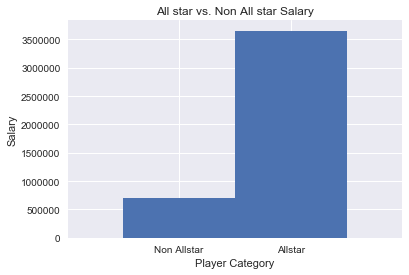

```python
categories = ["Non Allstar", "Allstar"]
values     = [ Salary_totalmean_nonallstar,  Allstar_salary_mean]
xs = np.arange(1, len(categories) + 1)
plt.bar(xs , values, width=1)
plt.xticks(xs, categories)
plt.xlim(0, len(categories) + 1)
plt.ylabel("Salary")
plt.xlabel('Player Category')
plt.title('All star vs. Non All star Salary')
plt.show()
```

It is clear from the above graph that the salary of a player who has represented an all star game atleast once is significantly higher when compared to one who hasn't been there.

#### 4. Which league, the National league or the American league has won the most world series title?

To analyze which league has won the world series the most number of times we'll have to take into consideration,the year of merger of NL and AL. The merger happened in 1903, with the winners of the AL and N L facing for the world series title,so data from the teams table from 1903 will be considered.

```python
#Data from the year 1903
Teams_1903=Teams[Teams['yearID']>=1903]
```

Teams that have won the world series have both the 'LgWin' and 'WSWin' column as 'Y' in the Teams.csv file

```python
#List of world series winners
f=Teams_1903[Teams_1903['LgWin']=='Y']
Worldseries_winners=f[f['WSWin']=='Y']
Worldseries_winners
```

|  | yearID | lgID | teamID | franchID | divID | Rank | G | Ghome | W | L | ... | DP | FP | name | park | attendance | BPF | PPF | teamIDBR | teamIDlahman45 | teamIDretro |
| --- | --- | --- | --- | --- | --- | --- | --- | --- | --- | --- | --- | --- | --- | --- | --- | --- | --- | --- | --- | --- | --- |
| 415 | 1903 | AL | BOS | BOS | NaN | 1 | 141 | 70.0 | 91 | 47 | ... | 86.0 | 0.959 | Boston Americans | Huntington Avenue Grounds | 379338.0 | 105 | 102 | BOS | BOS | BOS |
| 455 | 1905 | NL | NY1 | SFG | NaN | 1 | 155 | 76.0 | 105 | 48 | ... | 93.0 | 0.960 | New York Giants | Polo Grounds III | 552700.0 | 102 | 98 | NYG | NY1 | NY1 |
| 466 | 1906 | AL | CHA | CHW | NaN | 1 | 154 | 79.0 | 93 | 58 | ... | 80.0 | 0.963 | Chicago White Sox | South Side Park II | 585202.0 | 98 | 95 | CHW | CHA | CHA |
| 483 | 1907 | NL | CHN | CHC | NaN | 1 | 155 | 76.0 | 107 | 45 | ... | 110.0 | 0.967 | Chicago Cubs | West Side Park II | 422550.0 | 106 | 101 | CHC | CHN | CHN |
| 499 | 1908 | NL | CHN | CHC | NaN | 1 | 158 | 78.0 | 99 | 55 | ... | 76.0 | 0.969 | Chicago Cubs | West Side Park II | 665325.0 | 104 | 100 | CHC | CHN | CHN |
| 523 | 1909 | NL | PIT | PIT | NaN | 1 | 154 | 78.0 | 110 | 42 | ... | 100.0 | 0.964 | Pittsburgh Pirates | Exposition Park/Forbes Field | 534950.0 | 105 | 99 | PIT | PIT | PIT |
| 537 | 1910 | AL | PHA | OAK | NaN | 1 | 155 | 78.0 | 102 | 48 | ... | 117.0 | 0.965 | Philadelphia Athletics | Shibe Park | 588905.0 | 99 | 94 | PHA | PHA | PHA |
| 553 | 1911 | AL | PHA | OAK | NaN | 1 | 152 | 75.0 | 101 | 50 | ... | 100.0 | 0.963 | Philadelphia Athletics | Shibe Park | 605749.0 | 98 | 95 | PHA | PHA | PHA |
| 559 | 1912 | AL | BOS | BOS | NaN | 1 | 154 | 78.0 | 105 | 47 | ... | 88.0 | 0.957 | Boston Red Sox | Fenway Park I | 597096.0 | 105 | 102 | BOS | BOS | BOS |
| 585 | 1913 | AL | PHA | OAK | NaN | 1 | 153 | 76.0 | 96 | 57 | ... | 108.0 | 0.966 | Philadelphia Athletics | Shibe Park | 571896.0 | 98 | 94 | PHA | PHA | PHA |
| 595 | 1914 | NL | BSN | ATL | NaN | 1 | 158 | 79.0 | 94 | 59 | ... | 143.0 | 0.963 | Boston Braves | South End Grounds III | 382913.0 | 104 | 102 | BSN | BSN | BSN |
| 616 | 1915 | AL | BOS | BOS | NaN | 1 | 155 | 76.0 | 101 | 50 | ... | 95.0 | 0.964 | Boston Red Sox | Fenway Park I | 539885.0 | 97 | 95 | BOS | BOS | BOS |
| 639 | 1916 | AL | BOS | BOS | NaN | 1 | 156 | 78.0 | 91 | 63 | ... | 108.0 | 0.972 | Boston Red Sox | Fenway Park I | 496397.0 | 101 | 98 | BOS | BOS | BOS |
| 658 | 1917 | AL | CHA | CHW | NaN | 1 | 156 | 79.0 | 100 | 54 | ... | 117.0 | 0.968 | Chicago White Sox | Comiskey Park | 684521.0 | 102 | 100 | CHW | CHA | CHA |
| 671 | 1918 | AL | BOS | BOS | NaN | 1 | 126 | 70.0 | 75 | 51 | ... | 89.0 | 0.971 | Boston Red Sox | Fenway Park I | 249513.0 | 98 | 97 | BOS | BOS | BOS |
| 692 | 1919 | NL | CIN | CIN | NaN | 1 | 140 | 70.0 | 96 | 44 | ... | 98.0 | 0.974 | Cincinnati Reds | Crosley Field | 532501.0 | 97 | 95 | CIN | CIN | CIN |
| 709 | 1920 | AL | CLE | CLE | NaN | 1 | 154 | 78.0 | 98 | 56 | ... | 124.0 | 0.971 | Cleveland Indians | League Park II | 912832.0 | 104 | 101 | CLE | CLE | CLE |
| 727 | 1921 | NL | NY1 | SFG | NaN | 1 | 153 | 79.0 | 94 | 59 | ... | 155.0 | 0.971 | New York Giants | Polo Grounds IV | 973477.0 | 102 | 98 | NYG | NY1 | NY1 |
| 743 | 1922 | NL | NY1 | SFG | NaN | 1 | 156 | 79.0 | 93 | 61 | ... | 145.0 | 0.970 | New York Giants | Polo Grounds IV | 945809.0 | 102 | 98 | NYG | NY1 | NY1 |
| 760 | 1923 | AL | NYA | NYY | NaN | 1 | 152 | 76.0 | 98 | 54 | ... | 131.0 | 0.977 | New York Yankees | Yankee Stadium I | 1007066.0 | 103 | 100 | NYY | NYA | NYA |
| 782 | 1924 | AL | WS1 | MIN | NaN | 1 | 156 | 79.0 | 92 | 62 | ... | 149.0 | 0.972 | Washington Senators | Griffith Stadium I | 584310.0 | 98 | 96 | WSH | WS1 | WS1 |
| 795 | 1925 | NL | PIT | PIT | NaN | 1 | 153 | 77.0 | 95 | 58 | ... | 171.0 | 0.964 | Pittsburgh Pirates | Forbes Field | 804354.0 | 106 | 104 | PIT | PIT | PIT |
| 813 | 1926 | NL | SLN | STL | NaN | 1 | 156 | 79.0 | 89 | 65 | ... | 141.0 | 0.969 | St. Louis Cardinals | Sportsman's Park IV | 668428.0 | 104 | 103 | STL | SLN | SLN |
| 824 | 1927 | AL | NYA | NYY | NaN | 1 | 155 | 77.0 | 110 | 44 | ... | 123.0 | 0.969 | New York Yankees | Yankee Stadium I | 1164015.0 | 98 | 94 | NYY | NYA | NYA |
| 840 | 1928 | AL | NYA | NYY | NaN | 1 | 154 | 77.0 | 101 | 53 | ... | 136.0 | 0.967 | New York Yankees | Yankee Stadium I | 1072132.0 | 98 | 94 | NYY | NYA | NYA |
| 857 | 1929 | AL | PHA | OAK | NaN | 1 | 151 | 74.0 | 104 | 46 | ... | 117.0 | 0.975 | Philadelphia Athletics | Shibe Park | 839176.0 | 104 | 100 | PHA | PHA | PHA |
| 873 | 1930 | AL | PHA | OAK | NaN | 1 | 154 | 76.0 | 102 | 52 | ... | 121.0 | 0.976 | Philadelphia Athletics | Shibe Park | 721663.0 | 105 | 101 | PHA | PHA | PHA |
| 893 | 1931 | NL | SLN | STL | NaN | 1 | 154 | 78.0 | 101 | 53 | ... | 169.0 | 0.974 | St. Louis Cardinals | Sportsman's Park IV | 608535.0 | 105 | 103 | STL | SLN | SLN |
| 904 | 1932 | AL | NYA | NYY | NaN | 1 | 156 | 77.0 | 107 | 47 | ... | 124.0 | 0.969 | New York Yankees | Yankee Stadium I | 962320.0 | 96 | 92 | NYY | NYA | NYA |
| 919 | 1933 | NL | NY1 | SFG | NaN | 1 | 156 | 77.0 | 91 | 61 | ... | 156.0 | 0.973 | New York Giants | Polo Grounds IV | 604471.0 | 99 | 97 | NYG | NY1 | NY1 |
| ... | ... | ... | ... | ... | ... | ... | ... | ... | ... | ... | ... | ... | ... | ... | ... | ... | ... | ... | ... | ... | ... |
| 1959 | 1986 | NL | NYN | NYM | E | 1 | 162 | 81.0 | 108 | 54 | ... | 145.0 | 0.978 | New York Mets | Shea Stadium | 2767601.0 | 98 | 96 | NYM | NYN | NYN |
| 1981 | 1987 | AL | MIN | MIN | W | 1 | 162 | 81.0 | 85 | 77 | ... | 147.0 | 0.984 | Minnesota Twins | Hubert H Humphrey Metrodome | 2081976.0 | 103 | 103 | MIN | MIN | MIN |
| 2006 | 1988 | NL | LAN | LAD | W | 1 | 162 | 81.0 | 94 | 67 | ... | 126.0 | 0.977 | Los Angeles Dodgers | Dodger Stadium | 2980262.0 | 98 | 97 | LAD | LAN | LAN |
| 2038 | 1989 | AL | OAK | OAK | W | 1 | 162 | 81.0 | 99 | 63 | ... | 159.0 | 0.979 | Oakland Athletics | Oakland Coliseum | 2667225.0 | 97 | 95 | OAK | OAK | OAK |
| 2053 | 1990 | NL | CIN | CIN | W | 1 | 162 | 81.0 | 91 | 71 | ... | 126.0 | 0.983 | Cincinnati Reds | Riverfront Stadium | 2400892.0 | 105 | 105 | CIN | CIN | CIN |
| 2085 | 1991 | AL | MIN | MIN | W | 1 | 162 | 81.0 | 95 | 67 | ... | 161.0 | 0.985 | Minnesota Twins | Hubert H Humphrey Metrodome | 2293842.0 | 105 | 104 | MIN | MIN | MIN |
| 2124 | 1992 | AL | TOR | TOR | E | 1 | 162 | 81.0 | 96 | 66 | ... | 109.0 | 0.985 | Toronto Blue Jays | Skydome | 4028318.0 | 105 | 104 | TOR | TOR | TOR |
| 2152 | 1993 | AL | TOR | TOR | E | 1 | 162 | 81.0 | 95 | 67 | ... | 144.0 | 0.982 | Toronto Blue Jays | Skydome | 4057947.0 | 101 | 100 | TOR | TOR | TOR |
| 2181 | 1995 | NL | ATL | ATL | E | 1 | 144 | 72.0 | 90 | 54 | ... | 113.0 | 0.982 | Atlanta Braves | Atlanta-Fulton County Stadium | 2561831.0 | 103 | 102 | ATL | ATL | ATL |
| 2226 | 1996 | AL | NYA | NYY | E | 1 | 162 | 80.0 | 92 | 70 | ... | 146.0 | 0.985 | New York Yankees | Yankee Stadium II | 2250877.0 | 101 | 100 | NYY | NYA | NYA |
| 2247 | 1997 | NL | FLO | FLA | E | 2 | 162 | 81.0 | 92 | 70 | ... | 167.0 | 0.981 | Florida Marlins | Joe Robbie Stadium | 2364387.0 | 95 | 96 | FLA | FLO | FLO |
| 2283 | 1998 | AL | NYA | NYY | E | 1 | 162 | 81.0 | 114 | 48 | ... | 146.0 | 0.984 | New York Yankees | Yankee Stadium II | 2955193.0 | 97 | 95 | NYY | NYA | NYA |
| 2313 | 1999 | AL | NYA | NYY | E | 1 | 162 | 81.0 | 98 | 64 | ... | 130.0 | 0.982 | New York Yankees | Yankee Stadium II | 3292736.0 | 98 | 97 | NYY | NYA | NYA |
| 2343 | 2000 | AL | NYA | NYY | E | 1 | 161 | 80.0 | 87 | 74 | ... | 132.0 | 0.981 | New York Yankees | Yankee Stadium II | 3055435.0 | 99 | 98 | NYY | NYA | NYA |
| 2356 | 2001 | NL | ARI | ARI | W | 1 | 162 | 81.0 | 92 | 70 | ... | 148.0 | 0.986 | Arizona Diamondbacks | Bank One Ballpark | 2736451.0 | 108 | 107 | ARI | ARI | ARI |
| 2385 | 2002 | AL | ANA | ANA | W | 2 | 162 | 81.0 | 99 | 63 | ... | 151.0 | 0.986 | Anaheim Angels | Edison International Field | 2305547.0 | 100 | 99 | ANA | ANA | ANA |
| 2426 | 2003 | NL | FLO | FLA | E | 2 | 162 | 81.0 | 91 | 71 | ... | 162.0 | 0.987 | Florida Marlins | Pro Player Stadium | 1303215.0 | 98 | 98 | FLA | FLO | FLO |
| 2449 | 2004 | AL | BOS | BOS | E | 2 | 162 | 81.0 | 98 | 64 | ... | 129.0 | 0.981 | Boston Red Sox | Fenway Park II | 2837294.0 | 106 | 105 | BOS | BOS | BOS |
| 2479 | 2005 | AL | CHA | CHW | C | 1 | 162 | 81.0 | 99 | 63 | ... | 166.0 | 0.985 | Chicago White Sox | U.S. Cellular Field | 2342833.0 | 103 | 103 | CHW | CHA | CHA |
| 2530 | 2006 | NL | SLN | STL | C | 1 | 161 | 80.0 | 83 | 78 | ... | 170.0 | 0.984 | St. Louis Cardinals | Busch Stadium III | 3407104.0 | 99 | 99 | STL | SLN | SLN |
| 2538 | 2007 | AL | BOS | BOS | E | 1 | 162 | 81.0 | 96 | 66 | ... | 145.0 | 0.986 | Boston Red Sox | Fenway Park II | 2970755.0 | 106 | 105 | BOS | BOS | BOS |
| 2585 | 2008 | NL | PHI | PHI | E | 1 | 162 | 81.0 | 92 | 70 | ... | 142.0 | 0.985 | Philadelphia Phillies | Citizens Bank Park | 3422583.0 | 103 | 102 | PHI | PHI | PHI |
| 2612 | 2009 | AL | NYA | NYY | E | 1 | 162 | 81.0 | 103 | 59 | ... | 131.0 | 0.985 | New York Yankees | Yankee Stadium III | 3719358.0 | 105 | 103 | NYY | NYA | NYA |
| 2649 | 2010 | NL | SFN | SFG | W | 1 | 162 | 81.0 | 92 | 70 | ... | 110.0 | 0.988 | San Francisco Giants | AT&T Park | 3037443.0 | 101 | 101 | SFG | SFN | SFN |
| 2680 | 2011 | NL | SLN | STL | C | 2 | 162 | 81.0 | 90 | 72 | ... | 167.0 | 0.982 | St. Louis Cardinals | Busch Stadium III | 3093954.0 | 95 | 94 | STL | SLN | SLN |
| 2709 | 2012 | NL | SFN | SFG | W | 1 | 162 | 81.0 | 94 | 68 | ... | 134.0 | 0.981 | San Francisco Giants | AT&T Park | 3377371.0 | 88 | 88 | SFG | SFN | SFN |
| 2718 | 2013 | AL | BOS | BOS | E | 1 | 162 | 81.0 | 97 | 65 | ... | 142.0 | 0.987 | Boston Red Sox | Fenway Park II | 2833333.0 | 102 | 102 | BOS | BOS | BOS |
| 2769 | 2014 | NL | SFN | SFG | W | 2 | 162 | 81.0 | 88 | 74 | ... | 155.0 | 0.984 | San Francisco Giants | AT&T Park | 3368697.0 | 95 | 95 | SFG | SFN | SFN |
| 2786 | 2015 | AL | KCA | KCR | C | 1 | 162 | 81.0 | 95 | 67 | ... | 138.0 | 0.985 | Kansas City Royals | Kauffman Stadium | 2708549.0 | 104 | 103 | KCR | KCA | KCA |
| 2810 | 2016 | NL | CHN | CHC | C | 1 | 162 | 81.0 | 103 | 58 | ... | 116.0 | 0.983 | Chicago Cubs | Wrigley Field | 3232420.0 | 95 | 93 | CHC | CHN | CHN |

112 rows × 48 columns

The above code gives the list of world series winners since 1903.One thing visible from the above table is the missing of the year 1904 in the dataframe. On checking the complete list we find that 1994 is also missing from the table. It has already been covered that the world series did not happen for the year of 1994 and running the below code to look at the 1904 data we get Nan output for the 'WSWin' column for the year of 1904. Since no teams won the world series its safe to assume that it wasnt held that year.

```python
Teams_1903[Teams_1903['yearID']==1904]['WSWin']
```

```
431    NaN
432    NaN
433    NaN
434    NaN
435    NaN
436    NaN
437    NaN
438    NaN
439    NaN
440    NaN
441    NaN
442    NaN
443    NaN
444    NaN
445    NaN
446    NaN
Name: WSWin, dtype: object
```

```python
# Number of world series wins by AL and NL
AL_wins=0
NL_wins=0
for value in Worldseries_winners['lgID']:
    if value == 'AL':
        AL_wins=AL_wins+1
    else:
        NL_wins=NL_wins+1
print('The number of American League wins is {}'.format(AL_wins))
print('The number of National League wins is {}'.format(NL_wins))
```

```
The number of American League wins is 64
The number of National League wins is 48
```

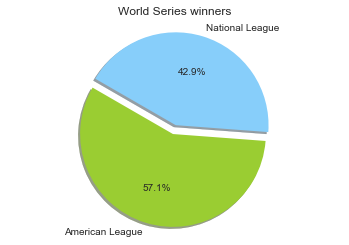

```python
# Setting up data
labels = 'American League', 'National League'
sizes = [AL_wins,NL_wins]
colors = ['yellowgreen','lightskyblue']
explode = (0.1, 0)  # explode 1st slice

# Pie Chart
plt.pie(sizes, explode=explode, labels=labels, colors=colors,
        autopct='%1.1f%%', shadow=True, startangle=150)
plt.title("World Series winners")
plt.axis('equal')
plt.show()
```

The above graph shows the percentage of world series wins by the 2 leagues

#### 5.What percent of people nominated for the Hall of Fame finally get voted into it?

```python
Hall_of_Fame=pd.read_csv('HallOfFame.csv')
```

```python
Hall_of_Fame.head()
```

|  | playerID | yearid | votedBy | ballots | needed | votes | inducted | category | needed_note |
| --- | --- | --- | --- | --- | --- | --- | --- | --- | --- |
| 0 | cobbty01 | 1936 | BBWAA | 226.0 | 170.0 | 222.0 | Y | Player | NaN |
| 1 | ruthba01 | 1936 | BBWAA | 226.0 | 170.0 | 215.0 | Y | Player | NaN |
| 2 | wagneho01 | 1936 | BBWAA | 226.0 | 170.0 | 215.0 | Y | Player | NaN |
| 3 | mathech01 | 1936 | BBWAA | 226.0 | 170.0 | 205.0 | Y | Player | NaN |
| 4 | johnswa01 | 1936 | BBWAA | 226.0 | 170.0 | 189.0 | Y | Player | NaN |

```python
#Total number od people nominated
Hall_of_Fame['inducted'].count()
```

```
4156
```

```python
#Total number of people inducted
Hall_of_Fame_Inducted=Hall_of_Fame[Hall_of_Fame['inducted']=='Y']

Hall_of_Fame_Inducted['inducted'].count()
```

```
317
```

```python
# Percent of people inducted into the Hall of Fame
Percent= ((Hall_of_Fame_Inducted['inducted'].count())/Hall_of_Fame['inducted'].count())*100

print ('The percentage of nominees inducted into the Hall of Fame is {}'.format(Percent))
```

```
The percentage of nominees inducted into the Hall of Fame is 7.627526467757459
```

Thus we can see that over the years only 7.63 % of the nominees have been inducted into the Hall of Fame

```
N    3839
Y     317
Name: inducted, dtype: int64
```

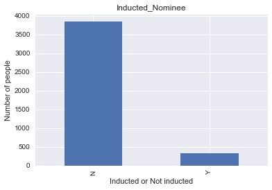

```python
Inducted_Nominee = Hall_of_Fame.inducted.value_counts()
Inducted_Nominee.plot(kind='bar')
plt.ylabel("Number of people")
plt.xlabel("Inducted or Not inducted")
plt.title("Inducted_Nominee");
Inducted_Nominee
```

As visible from the 'Hall_of_Fame_Inducted' data frame , the person inducted into the Hall of Fame is not always a player. The category varies.

```python
#The various categories with the count
Category_count=Hall_of_Fame_Inducted.groupby('category',as_index=False).count()
Category_count
```

|  | category | playerID | yearid | votedBy | ballots | needed | votes | inducted | needed_note |
| --- | --- | --- | --- | --- | --- | --- | --- | --- | --- |
| 0 | Manager | 23 | 23 | 23 | 0 | 0 | 0 | 23 | 0 |
| 1 | Pioneer/Executive | 34 | 34 | 34 | 0 | 0 | 0 | 34 | 0 |
| 2 | Player | 250 | 250 | 250 | 122 | 119 | 122 | 250 | 3 |
| 3 | Umpire | 10 | 10 | 10 | 0 | 0 | 0 | 10 | 0 |

```python
#List of the category and count
Category_count['playerID'].values
Category_list= Category_count[['category','playerID']].values.tolist()
Category_list
```

```
[['Manager', 23], ['Pioneer/Executive', 34], ['Player', 250], ['Umpire', 10]]
```

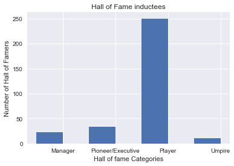

```python
#Graph of the category count
labels, values = zip(*Category_list)
indexes = np.arange(len(labels))
width = 0.5

plt.bar(indexes, values, width)
plt.xticks(indexes + width * 0.5, labels)
plt.ylabel("Count")
plt.title("Hall of Fame inductees");
plt.ylabel("Number of Hall of Famers")
plt.xlabel("Hall of fame Categories")
```

The above graph shows the categories of Hall of fame inductees and the count over the years.

###### 6.How are the performance stats for a player in the Hall of Fame?

To analyze the performance stats we must consider the Hall of Fame players under the category 'player'. Performance stats analyzed for the players are their batting stats and pitiching stats.

```python
Batting=pd.read_csv('Batting.csv')
```

```python
Hall_of_Fame_Inducted_Player=Hall_of_Fame_Inducted[Hall_of_Fame_Inducted['category']=='Player']
Hall_of_Fame_Inducted_Player.head()
```

|  | playerID | yearid | votedBy | ballots | needed | votes | inducted | category | needed_note |
| --- | --- | --- | --- | --- | --- | --- | --- | --- | --- |
| 0 | cobbty01 | 1936 | BBWAA | 226.0 | 170.0 | 222.0 | Y | Player | NaN |
| 1 | ruthba01 | 1936 | BBWAA | 226.0 | 170.0 | 215.0 | Y | Player | NaN |
| 2 | wagneho01 | 1936 | BBWAA | 226.0 | 170.0 | 215.0 | Y | Player | NaN |
| 3 | mathech01 | 1936 | BBWAA | 226.0 | 170.0 | 205.0 | Y | Player | NaN |
| 4 | johnswa01 | 1936 | BBWAA | 226.0 | 170.0 | 189.0 | Y | Player | NaN |

```python
#Merging the Batting data frame and Hall of fame player data frame
Batting_HallofFame=Batting.merge(Hall_of_Fame_Inducted_Player, on='playerID', how='right')
```

```python
Batting_HallofFame.head()
```

|  | playerID | yearID | stint | teamID | lgID | G | AB | R | H | 2B | ... | SF | GIDP | yearid | votedBy | ballots | needed | votes | inducted | category | needed_note |
| --- | --- | --- | --- | --- | --- | --- | --- | --- | --- | --- | --- | --- | --- | --- | --- | --- | --- | --- | --- | --- | --- |
| 0 | ansonca01 | 1871.0 | 1.0 | RC1 | NaN | 25.0 | 120.0 | 29.0 | 39.0 | 11.0 | ... | NaN | NaN | 1939 | Old Timers | NaN | NaN | NaN | Y | Player | NaN |
| 1 | ansonca01 | 1872.0 | 1.0 | PH1 | NaN | 46.0 | 217.0 | 60.0 | 90.0 | 10.0 | ... | NaN | NaN | 1939 | Old Timers | NaN | NaN | NaN | Y | Player | NaN |
| 2 | ansonca01 | 1873.0 | 1.0 | PH1 | NaN | 52.0 | 254.0 | 53.0 | 101.0 | 9.0 | ... | NaN | NaN | 1939 | Old Timers | NaN | NaN | NaN | Y | Player | NaN |
| 3 | ansonca01 | 1874.0 | 1.0 | PH1 | NaN | 55.0 | 259.0 | 51.0 | 87.0 | 8.0 | ... | NaN | NaN | 1939 | Old Timers | NaN | NaN | NaN | Y | Player | NaN |
| 4 | ansonca01 | 1875.0 | 1.0 | PH1 | NaN | 69.0 | 326.0 | 84.0 | 106.0 | 15.0 | ... | NaN | NaN | 1939 | Old Timers | NaN | NaN | NaN | Y | Player | NaN |

5 rows × 30 columns

```python
Batting_HallofFame_Stats=Batting_HallofFame.groupby('playerID',as_index=False)[['AB','R','H','2B','3B','HR']].mean()
```

```python
Batting_HallofFame_Stats
```

|  | playerID | AB | R | H | 2B | 3B | HR |
| --- | --- | --- | --- | --- | --- | --- | --- |
| 0 | aaronha01 | 537.565217 | 94.521739 | 163.956522 | 27.130435 | 4.260870 | 32.826087 |
| 1 | alexape01 | 86.190476 | 7.333333 | 18.000000 | 2.857143 | 0.619048 | 0.523810 |
| 2 | alomaro01 | 477.526316 | 79.368421 | 143.368421 | 26.526316 | 4.210526 | 11.052632 |
| 3 | ansonca01 | 380.629630 | 73.925926 | 126.592593 | 21.518519 | 5.259259 | 3.592593 |
| 4 | aparilu01 | 568.333333 | 74.166667 | 148.722222 | 21.888889 | 5.111111 | 4.611111 |
| 5 | applilu01 | 442.800000 | 65.950000 | 137.450000 | 22.000000 | 5.100000 | 2.250000 |
| 6 | ashburi01 | 557.666667 | 88.133333 | 171.600000 | 21.133333 | 7.266667 | 1.933333 |
| 7 | averiea01 | 453.785714 | 87.428571 | 144.214286 | 28.642857 | 9.142857 | 17.000000 |
| 8 | bagweje01 | 519.800000 | 101.133333 | 154.266667 | 32.533333 | 2.133333 | 29.933333 |
| 9 | bakerfr01 | 460.307692 | 68.230769 | 141.384615 | 24.230769 | 7.923077 | 7.384615 |
| 10 | bancrda01 | 422.470588 | 61.647059 | 117.882353 | 18.823529 | 4.529412 | 1.882353 |
| 11 | bankser01 | 495.842105 | 68.684211 | 135.947368 | 21.421053 | 4.736842 | 26.947368 |
| 12 | becklja01 | 433.000000 | 72.727273 | 133.181818 | 21.500000 | 11.045455 | 3.909091 |
| 13 | bellco99 | NaN | NaN | NaN | NaN | NaN | NaN |
| 14 | benchjo01 | 450.470588 | 64.176471 | 120.470588 | 22.411765 | 1.411765 | 22.882353 |
| 15 | bendech01 | 71.687500 | 6.375000 | 15.187500 | 2.500000 | 0.625000 | 0.375000 |
| 16 | berrayo01 | 397.631579 | 61.842105 | 113.157895 | 16.894737 | 2.578947 | 18.842105 |
| 17 | biggicr01 | 543.800000 | 92.200000 | 153.000000 | 33.400000 | 2.750000 | 14.550000 |
| 18 | blylebe01 | 18.791667 | 0.791667 | 2.458333 | 0.291667 | 0.000000 | 0.000000 |
| 19 | boggswa01 | 510.000000 | 84.055556 | 167.222222 | 32.111111 | 3.388889 | 6.555556 |
| 20 | bottoji01 | 466.937500 | 73.562500 | 144.562500 | 29.062500 | 9.437500 | 13.687500 |
| 21 | boudrlo01 | 401.933333 | 57.400000 | 118.600000 | 25.666667 | 4.400000 | 4.533333 |
| 22 | bresnro01 | 248.944444 | 37.888889 | 69.555556 | 12.111111 | 3.944444 | 1.444444 |
| 23 | brettge01 | 492.809524 | 75.380952 | 150.190476 | 31.666667 | 6.523810 | 15.095238 |
| 24 | brocklo01 | 516.600000 | 80.500000 | 151.150000 | 24.300000 | 7.050000 | 7.450000 |
| 25 | broutda01 | 335.550000 | 76.150000 | 114.800000 | 23.000000 | 10.250000 | 5.300000 |
| 26 | brownmo01 | 76.200000 | 6.200000 | 15.666667 | 1.333333 | 0.733333 | 0.133333 |
| 27 | brownra99 | NaN | NaN | NaN | NaN | NaN | NaN |
| 28 | brownwi02 | 67.000000 | 4.000000 | 12.000000 | 3.000000 | 0.000000 | 1.000000 |
| 29 | bunniji01 | 70.833333 | 4.555556 | 11.833333 | 1.166667 | 0.222222 | 0.388889 |
| ... | ... | ... | ... | ... | ... | ... | ... |
| 220 | thompsa01 | 398.933333 | 83.733333 | 131.933333 | 22.666667 | 10.666667 | 8.466667 |
| 221 | tinkejo01 | 428.933333 | 51.600000 | 112.466667 | 17.533333 | 7.600000 | 2.066667 |
| 222 | torricr99 | NaN | NaN | NaN | NaN | NaN | NaN |
| 223 | traynpi01 | 444.647059 | 69.588235 | 142.117647 | 21.823529 | 9.647059 | 3.411765 |
| 224 | vanceda01 | 53.944444 | 3.777778 | 8.111111 | 1.277778 | 0.055556 | 0.388889 |
| 225 | vaughar01 | 473.000000 | 83.785714 | 150.214286 | 25.428571 | 9.142857 | 6.857143 |
| 226 | wadderu01 | 76.142857 | 4.357143 | 12.285714 | 2.071429 | 0.714286 | 0.285714 |
| 227 | wagneho01 | 496.666667 | 82.666667 | 162.619048 | 30.476190 | 12.000000 | 4.809524 |
| 228 | wallabo01 | 344.720000 | 42.280000 | 92.360000 | 15.640000 | 5.720000 | 1.360000 |
| 229 | walshed01 | 77.714286 | 6.642857 | 15.000000 | 2.714286 | 0.714286 | 0.214286 |
| 230 | wanerll01 | 370.095238 | 57.190476 | 117.095238 | 13.380952 | 5.619048 | 1.285714 |
| 231 | wanerpa01 | 429.954545 | 73.954545 | 143.272727 | 27.500000 | 8.681818 | 5.136364 |
| 232 | wardjo01 | 449.823529 | 82.823529 | 123.764706 | 13.588235 | 5.647059 | 1.529412 |
| 233 | welchmi01 | 169.307692 | 20.615385 | 37.846154 | 7.153846 | 1.230769 | 0.923077 |
| 234 | wellswi99 | NaN | NaN | NaN | NaN | NaN | NaN |
| 235 | wheatza01 | 479.263158 | 67.842105 | 151.789474 | 25.052632 | 9.052632 | 6.947368 |
| 236 | whitede01 | 331.200000 | 57.000000 | 103.300000 | 13.400000 | 4.800000 | 1.150000 |
| 237 | wilheho01 | 16.615385 | 0.923077 | 1.461538 | 0.115385 | 0.038462 | 0.038462 |
| 238 | willibi01 | 519.444444 | 78.333333 | 150.611111 | 24.111111 | 4.888889 | 23.666667 |
| 239 | willijo99 | NaN | NaN | NaN | NaN | NaN | NaN |
| 240 | willite01 | 405.578947 | 94.631579 | 139.684211 | 27.631579 | 3.736842 | 27.421053 |
| 241 | willivi01 | 114.846154 | 8.230769 | 19.076923 | 1.461538 | 0.307692 | 0.076923 |
| 242 | wilsoha01 | 366.153846 | 68.000000 | 112.384615 | 20.461538 | 5.153846 | 18.769231 |
| 243 | wilsoju99 | NaN | NaN | NaN | NaN | NaN | NaN |
| 244 | winfida01 | 478.391304 | 72.565217 | 135.217391 | 23.478261 | 3.826087 | 20.217391 |
| 245 | wynnea01 | 74.086957 | 5.913043 | 15.869565 | 2.565217 | 0.217391 | 0.739130 |
| 246 | yastrca01 | 521.217391 | 78.956522 | 148.652174 | 28.086957 | 2.565217 | 19.652174 |
| 247 | youngcy01 | 128.695652 | 14.130435 | 27.086957 | 3.782609 | 1.521739 | 0.782609 |
| 248 | youngro01 | 462.700000 | 81.200000 | 149.100000 | 23.600000 | 9.300000 | 4.200000 |
| 249 | yountro01 | 550.400000 | 81.600000 | 157.100000 | 29.150000 | 6.300000 | 12.550000 |

250 rows × 7 columns

As visible from the output of the above code some players are recording **nan** as their batting stats.Looking into this, is required.

```python
#List of playerID's with nan as data
Nan_values=[]
for index, row in Batting_HallofFame_Stats.iterrows():
    if row['AB'] != row['AB']:
        (Nan_values.append(row['playerID']))
Nan_values
```

```
['bellco99',
 'brownra99',
 'charlos99',
 'coopean99',
 'dandrra99',
 'dayle99',
 'dihigma99',
 'fostebi99',
 'gibsojo99',
 'grantfr99',
 'hillpe99',
 'johnsju99',
 'leonabu99',
 'lloydpo99',
 'mackebi99',
 'mendejo99',
 'roganbu99',
 'santolo99',
 'smithhi99',
 'steartu99',
 'suttlmu99',
 'taylobe99',
 'torricr99',
 'wellswi99',
 'willijo99',
 'wilsoju99']
```

```python
#Looking for the above players in the Batting.csv file
for ID in Nan_values:
    if ID in Batting['playerID']:
        print ('The {} is in the table'.format(ID))
```

The above code produced no output meaning that there is no batting record of those players in the Batting.csv file.

```python
#Looking up those player data in the Hall of Fame csv file.

for index, row in Hall_of_Fame_Inducted_Player.iterrows():
    if row['playerID'] in Nan_values:
        print (row['votedBy'])
```

```
Negro League
Negro League
Negro League
Negro League
Negro League
Negro League
Negro League
Veterans
Veterans
Veterans
Veterans
Veterans
Veterans
Veterans
Veterans
Negro League
Negro League
Negro League
Negro League
Negro League
Negro League
Negro League
Negro League
Negro League
Negro League
Negro League
```

```python
#Dropping nan
Batting_HallofFame_Stats=Batting_HallofFame_Stats.dropna()
```

One important stat to consider to gauge a player's batting ability is the **Batting Average**. Batting Average is given by the total **Hits** divided by the total **At Bats** for the player.

```python
(Batting_HallofFame_Stats['H']/Batting_HallofFame_Stats['AB']).mean()
```

```
0.26384653948352393
```

Next let's look at the Pitching stats of Hall of Famers from the Pitching.csv file.

```python
Pitching=pd.read_csv('Pitching.csv')
```

```python
Pitching.head()
```

|  | playerID | yearID | stint | teamID | lgID | W | L | G | GS | CG | ... | IBB | WP | HBP | BK | BFP | GF | R | SH | SF | GIDP |
| --- | --- | --- | --- | --- | --- | --- | --- | --- | --- | --- | --- | --- | --- | --- | --- | --- | --- | --- | --- | --- | --- |
| 0 | bechtge01 | 1871 | 1 | PH1 | NaN | 1 | 2 | 3 | 3 | 2 | ... | NaN | NaN | NaN | 0 | NaN | NaN | 42 | NaN | NaN | NaN |
| 1 | brainas01 | 1871 | 1 | WS3 | NaN | 12 | 15 | 30 | 30 | 30 | ... | NaN | NaN | NaN | 0 | NaN | NaN | 292 | NaN | NaN | NaN |
| 2 | fergubo01 | 1871 | 1 | NY2 | NaN | 0 | 0 | 1 | 0 | 0 | ... | NaN | NaN | NaN | 0 | NaN | NaN | 9 | NaN | NaN | NaN |
| 3 | fishech01 | 1871 | 1 | RC1 | NaN | 4 | 16 | 24 | 24 | 22 | ... | NaN | NaN | NaN | 0 | NaN | NaN | 257 | NaN | NaN | NaN |
| 4 | fleetfr01 | 1871 | 1 | NY2 | NaN | 0 | 1 | 1 | 1 | 1 | ... | NaN | NaN | NaN | 0 | NaN | NaN | 21 | NaN | NaN | NaN |

5 rows × 30 columns

```python
#Merging the Pitching data frame and Hall of fame player data frame
Pitching_HallofFame=Pitching.merge(Hall_of_Fame_Inducted_Player, on='playerID', how='right')
```

```python
Pitching_HallofFame.head()
```

|  | playerID | yearID | stint | teamID | lgID | W | L | G | GS | CG | ... | SF | GIDP | yearid | votedBy | ballots | needed | votes | inducted | category | needed_note |
| --- | --- | --- | --- | --- | --- | --- | --- | --- | --- | --- | --- | --- | --- | --- | --- | --- | --- | --- | --- | --- | --- |
| 0 | galvipu01 | 1875.0 | 1.0 | SL2 | NaN | 4.0 | 2.0 | 8.0 | 7.0 | 7.0 | ... | NaN | NaN | 1965 | Veterans | NaN | NaN | NaN | Y | Player | NaN |
| 1 | galvipu01 | 1879.0 | 1.0 | BFN | NL | 37.0 | 27.0 | 66.0 | 66.0 | 65.0 | ... | NaN | NaN | 1965 | Veterans | NaN | NaN | NaN | Y | Player | NaN |
| 2 | galvipu01 | 1880.0 | 1.0 | BFN | NL | 20.0 | 35.0 | 58.0 | 54.0 | 46.0 | ... | NaN | NaN | 1965 | Veterans | NaN | NaN | NaN | Y | Player | NaN |
| 3 | galvipu01 | 1881.0 | 1.0 | BFN | NL | 28.0 | 24.0 | 56.0 | 53.0 | 48.0 | ... | NaN | NaN | 1965 | Veterans | NaN | NaN | NaN | Y | Player | NaN |
| 4 | galvipu01 | 1882.0 | 1.0 | BFN | NL | 28.0 | 23.0 | 52.0 | 51.0 | 48.0 | ... | NaN | NaN | 1965 | Veterans | NaN | NaN | NaN | Y | Player | NaN |

5 rows × 38 columns

In measuring the effectiveness of a pitcher, one of the many stats analyzed is the ERA(Earned Runs allowed). Lets look into the ERA of Hall of Famers

```python
Pitching_HallofFame_Stats=Pitching_HallofFame.groupby('playerID',as_index=False)['ERA'].mean()
```

```python
Pitching_HallofFame_Stats.head()
```

|  | playerID | ERA |
| --- | --- | --- |
| 0 | aaronha01 | NaN |
| 1 | alexape01 | 2.972381 |
| 2 | alomaro01 | NaN |
| 3 | ansonca01 | 9.000000 |
| 4 | aparilu01 | NaN |

Lets print out the players with nan as ERA

```python
# Looking up the players with nan as ERA
Nan_values_pitching=[]
for index, row in Pitching_HallofFame_Stats.iterrows():
    if row['ERA'] != row['ERA']:
        (Nan_values_pitching.append(row['playerID']))
Nan_values_pitching
for ID in Nan_values_pitching:
    if ID in Pitching['playerID']:
        print ('The {} is in the table'.format(ID))
```

The above code produced no output which means the pitching stats for those players werent recorded at all. These players are excluded from the data frame.

```python
Pitching_HallofFame_Stats=Pitching_HallofFame_Stats.dropna()
Pitching_HallofFame_Stats.head()
```

|  | playerID | ERA |
| --- | --- | --- |
| 1 | alexape01 | 2.972381 |
| 3 | ansonca01 | 9.000000 |
| 12 | becklja01 | 6.750000 |
| 15 | bendech01 | 3.444375 |
| 18 | blylebe01 | 3.454167 |

```python
Overall_Stats_HallofFame=Batting_HallofFame_Stats.merge(Pitching_HallofFame_Stats, on='playerID',how='outer')
```

```python
Batting_Pitching_Stats_HallofFame=pd.DataFrame(columns=['playerID','Batting Average','ERA'])
for index, row in Overall_Stats_HallofFame.iterrows():
    Batting_Pitching_Stats_HallofFame=Batting_Pitching_Stats_HallofFame.append({
                   "playerID": row['playerID'],
                    "Batting Average":  (row['H']/row['AB']),
                    "ERA": row['ERA']
                         },ignore_index=True)
Batting_Pitching_Stats_HallofFame
League_BattingAverage_mean=(Batting['H']/Batting['AB']).mean()
League_ERA_mean=Pitching['ERA'].mean()
print ('Batting Average for the league is {}'.format(League_BattingAverage_mean))
print ('ERA mean for the league is {}'.format(League_ERA_mean))
```

```
Batting Average for the league is 0.20877884782625278
ERA mean for the league is 5.073269376476365
```

```python
Batting_Pitching_Stats_HallofFame.describe()
```

|  | Batting Average | ERA |
| --- | --- | --- |
| count | 224.000000 | 93.000000 |
| mean | 0.263847 | 3.676276 |
| std | 0.065052 | 2.405337 |
| min | 0.087963 | 0.000000 |
| 25% | 0.214774 | 2.998333 |
| 50% | 0.284605 | 3.375000 |
| 75% | 0.311868 | 3.721000 |
| max | 0.366363 | 18.535000 |

Comparing the Batting Average and ERA for Hall of Famers to the league average we find that Players inducted into the Hall of Fame tend to have a higher Batting Average or a lower ERA.

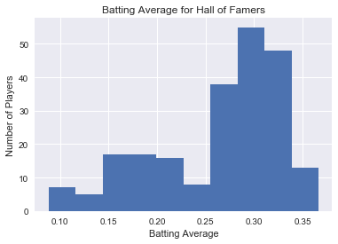

```python
Batting_Pitching_Stats_HallofFame['Batting Average'].hist()
plt.ylabel('Number of Players')
plt.xlabel('Batting Average')
plt.title('Batting Average for Hall of Famers')
```

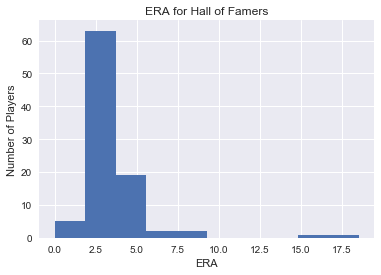

```python
Batting_Pitching_Stats_HallofFame['ERA'].hist()
plt.ylabel('Number of Players')
plt.xlabel('ERA')
plt.title('ERA for Hall of Famers')
```

# Limitations:

1. The salaries of players in the Salaries.csv file were recorded only from the year 1985. The salaries from the previous years were missing. So the mean salary curve could look different from the one in the report had those values been included.
2. Batting and Pitching stats of certain players were missing. Especially those from leagues like the Negro league. Stats of Hall of Famers from these leagues couldn't be analyzed. Hence the Batting Average and the ERA could have differed from the once mentioned in the report.
3. Removing the names of Hall of Famers with no batting or pitching records caused additional time and also needed additional code.

# Conclusion:

1. The average league attendance has increased over the years but has also witnessed sudden drop offs in certain years.
2. The avearge salary of basball ball players has increased almost exponentially over the years.
3. The average salary of a player who has been in an all star game atleast once is 5.2 times higher than the one who hasn;t been to the game.
4. The American league has won the most number of world series title.
5. Only 7.63% of the total number of people nominated to the Hall of Fame are finally nominated into it.
6. Players aren't the only once inducted into the Hall of Fame. Pioneers/Executives, Umpires, managers are also inducted.
7. Players in the Hall of Fame tend to have a higher Batting Average or a lower ERA.